# PABLO GARCIA DATA SCIENCE PORTFOLIO

## Gabrica - Data Analysis, Visualisation, Dimension reduction and Cluster Analysis

This project was part of a customer experience consultancy made by GRUPO LAERA. The consultancy determined how GABRICA S.A.S must handle their customers based on the customer’s type, customer relationship and customer spending amounts. Part of the outcomes was a cluster analysis to establish an efficient approach to the customers. GABRICA S.A.S is a Colombian firm which distributes standard pet food, medical pet food, pet medication, pet accesories among others types of products. Their customers are divided in pet shops, clinics, website stores and common stores.

## Introduction

In this project, first I analized the data which include customers spendings, products lines, products portfolios and if the product bought by the customers was a VIP or standard category product. Second, I did some feature engineering and data cleansing in order to define a better dataset to the future statistical analysis. Finally I did a PCA analysis trying to reduce dimensions of the research, and a cluster analysis to compare with current segmentation and determine future steps in the consultancy. The process to began with the gathering of the data based on financial, commercial and logistics management reports. Then after some data arrangements, the data was import to R to perform the whole anaysis.

The data was separated in three sets: * Amount Sales (monetary) * Amount Sales (inventory) * Demographics and segmentation

```r
library(gridExtra)
```

First I wanted to understand the structure of each dataset:

```r
glimpse(Portfolio_vip_standar)
```

```
Observations: 2,233
Variables: 7
$ Row.Labels <dbl> 215474, 1364460, 2231446, 2530280, 2889753, 3103803, 3207602, 3349713, 36166...
$ GENERAL    <int> 2, 4, 33, 10, 98, 160, 18, 8, NA, 11, 2, 2, 57, 79, 45, 73, 153, 17, 24, 34,...
$ VIP        <int> NA, 37, 70, 31, 186, 153, 45, 4, 15, NA, 2, NA, 58, 70, 56, 165, 96, 21, 11,...
$ DORADO     <int> NA, 12, 40, 15, 56, 33, 20, 5, 8, 3, NA, 2, 2, 15, 31, 81, 27, 10, 12, 80, 5...
$ EQUINO     <int> NA, NA, NA, NA, NA, NA, NA, NA, NA, NA, NA, NA, NA, NA, NA, NA, NA, NA, NA, ...
$ ESTELAR    <int> 2, 16, 22, 5, 99, 222, 25, 3, 7, 3, 3, NA, 64, 120, 13, 52, 157, 11, 6, -8, ...
$ PLATINO    <int> NA, 13, 41, 21, 129, 58, 18, 4, NA, 5, 1, NA, 49, 14, 57, 105, 65, 17, 17, 4...
```

```r
Portfolio_vip_standar<-Portfolio_vip_standar %>% mutate(`Row Labels`=as.character(`Row Labels`))
```

[output not shown]

```r
glimpse(Portfolio_vip_standar)
```

```
Observations: 2,233
Variables: 7
$ Customer_id <chr> "215474", "1364460", "2231446", "2530280", "2889753", "3103803", "3207602",...
$ GENERAL     <int> 2, 4, 33, 10, 98, 160, 18, 8, NA, 11, 2, 2, 57, 79, 45, 73, 153, 17, 24, 34...
$ VIP         <int> NA, 37, 70, 31, 186, 153, 45, 4, 15, NA, 2, NA, 58, 70, 56, 165, 96, 21, 11...
$ DORADO      <int> NA, 12, 40, 15, 56, 33, 20, 5, 8, 3, NA, 2, 2, 15, 31, 81, 27, 10, 12, 80, ...
$ EQUINO      <int> NA, NA, NA, NA, NA, NA, NA, NA, NA, NA, NA, NA, NA, NA, NA, NA, NA, NA, NA,...
$ ESTELAR     <int> 2, 16, 22, 5, 99, 222, 25, 3, 7, 3, 3, NA, 64, 120, 13, 52, 157, 11, 6, -8,...
$ PLATINO     <int> NA, 13, 41, 21, 129, 58, 18, 4, NA, 5, 1, NA, 49, 14, 57, 105, 65, 17, 17, ...
```

Before joining the tables, a little clarification of the data: * Customer_sales is the total value spent in a particular category of products during three months. * info_customers has the current segmentation Gabrica uses to classify their customers, and the location of the customer. Their current customers groups is based on commercial relationship and customer influence in the market. * Portfolio_vip_standar is the total amount of products each customer bought during the three months of analysis. Additionally, the goods are divived in two categories: type of good and type of portfolio. The sum of ‘General’ and ‘VIP’ (type of good) is the same as the sum of ‘Dorado’, ‘Equino’, ‘Estelar’, ‘Platino’ for each customer.

Unfortunately, the data was not recent and in some cases without consistency. So I had to determine which historical values to use and how they related between them.

```r
glimpse(customersData)
```

```
Observations: 838
Variables: 14
$ Customer_ID           <chr> "830024429", "860069284", "900024852", "900167786", "800034614", ...
$ Food.Dog              <int> 671648459, 771151187, 498528320, 405502876, 252342194, 205626236,...
$ Food.Cat              <int> 327679426, 290339466, 268784014, 241273561, 95201157, 95761778, 8...
$ Medical.treatment.Dog <int> 583247959, 416540258, 375305763, 174701363, 113653529, 130564432,...
$ Snacks                <int> 14334890, 22601701, 10059591, 11486101, 3612150, 8275660, 2898637...
$ Medical               <int> 54917990, 137390066, 115184427, 31022272, 39696060, 21086327, 495...
$ GENERAL               <int> 645, 1881, 788, 145, 511, 355, 401, 712, 331, 374, 161, 172, 285,...
$ VIP                   <int> 1589, 775, 1491, 104, 416, 246, 502, 1111, 322, 773, 408, 181, 21...
$ DORADO                <int> 961, 468, 891, 69, 168, 149, 192, 452, 125, 248, 221, 124, 64, 24...
$ EQUINO                <int> 4, 20, 17, 2, NA, NA, NA, 2, 4, NA, 2, 21, 25, 1, 1, NA, NA, NA, ...
$ ESTELAR               <int> 312, 1361, 652, 73, 440, 155, 309, 725, 186, 287, 133, 87, 124, 2...
$ PLATINO               <int> 957, 807, 719, 105, 319, 297, 402, 644, 338, 612, 213, 121, 290, ...
$ based_segment         <fctr> PLAN DE NEGOCIO, PLAN DE NEGOCIO, ALIADO, ALIADO, PLAN DE NEGOCI...
$ region                <fctr> Bogota, Bogota, Bogota, Medellin, Cali, Bogota, Bogota, Bogota, ...
```

Finally, with the final dataset defined, it was evident the loss of data based on the reasons explain before. Nevertheless, it was enough to made a good data analysis and evalute good conclusions. ## Data Analysis Initially, I decided to look the monetary variables since the majority of the issues found throughout the consultancy was about relationship and delivery of the goods.

```r
summary(customersData)
```

```
 Customer_ID           Food.Dog            Food.Cat         Medical.treatment.Dog
 Length:838         Min.   :    30570   Min.   :    16500   Min.   :    12420
 Class :character   1st Qu.:  1023048   1st Qu.:   711575   1st Qu.:   404990
 Mode  :character   Median :  2587225   Median :  1634892   Median :  1082198
                    Mean   : 10948025   Mean   :  6058506   Mean   :  6247431
                    3rd Qu.:  7204054   3rd Qu.:  3869084   3rd Qu.:  2978790
                    Max.   :771151187   Max.   :327679426   Max.   :583247959
                    NA's   :4           NA's   :7           NA's   :14
     Snacks            Medical             GENERAL             VIP              DORADO
 Min.   :    2351   Min.   :    11450   Min.   :  -2.00   Min.   :   1.00   Min.   :  1.00
 1st Qu.:   47785   1st Qu.:   438175   1st Qu.:  21.00   1st Qu.:  31.00   1st Qu.: 11.00
 Median :  108820   Median :  1039640   Median :  41.00   Median :  57.00   Median : 21.00
 Mean   :  427341   Mean   :  2723048   Mean   :  73.28   Mean   :  86.34   Mean   : 34.43
 3rd Qu.:  283218   3rd Qu.:  2412958   3rd Qu.:  87.00   3rd Qu.: 103.00   3rd Qu.: 41.00
 Max.   :22601701   Max.   :137390066   Max.   :1881.00   Max.   :1589.00   Max.   :961.00
 NA's   :190        NA's   :22          NA's   :5         NA's   :1         NA's   :20
     EQUINO          ESTELAR           PLATINO               based_segment         region
 Min.   : 1.000   Min.   :  -1.00   Min.   :-19.00   Estándar       :442   Bogota     :428
 1st Qu.: 1.000   1st Qu.:  13.00   1st Qu.: 24.00   PLAN DE NEGOCIO:179   Bucaramanga: 79
 Median : 2.000   Median :  30.00   Median : 45.00   ALIADO         :138   Cali       :124
 Mean   : 5.926   Mean   :  56.77   Mean   : 69.77   PLAN_NEGOCIO   : 40   Medellin   :207
 3rd Qu.: 5.000   3rd Qu.:  67.00   3rd Qu.: 86.00   Aliado         : 27
 Max.   :33.000   Max.   :1361.00   Max.   :957.00   HN             :  6
 NA's   :784      NA's   :14        NA's   :6        (Other)        :  6
```

Comparing the median and mean values in each feature I noticed that all of them presents outliers since the mean is higher in all cases. In addition, probably it would be a good idea to reduce the number of features in our analysis. Another point to mention was the NAs values, all of them represent 0 items purchase during the period of the data.

Taking a look to the ‘based_segment’ feature, it is important to notice that there are repeated values with slightly differences in the grammar and caps letters, for example ‘Aliado’ and ‘ALIADO’, and ‘PLAN DE NEGOCIO’ and ‘PLAN_NEGOCIO’. Additionally, I found that the employees were took into account in the customers database (‘EMPLEADO’). Since the employees are not part of my analysis I decidet to remove those registers from the data. Inactive customers (‘INACTIVOS’) and ‘HN’ were excluded too.

```r
summary(customersData$based_segment)
```

```
               0           Aliado           ALIADO         EMPLEADO         Estándar
               0               27              138                3              442
              HN        INACTIVOS  PLAN DE NEGOCIO PLAN DE NEGOCIO      PLAN_NEGOCIO
               6                1              179                2               40
```

```r
summary(customersData$based_segment)
```

```
               0           Aliado           ALIADO         EMPLEADO         Estándar
               0                0              165                0              442
              HN        INACTIVOS  PLAN DE NEGOCIO PLAN DE NEGOCIO      PLAN_NEGOCIO
               0                0                0                0              221
```

The whole analysis was focus on ‘ALIADO’, ‘PLAN_NEGOCIO’ and ‘Estándar’ based_segment values.

From our initial summary view we noticed that all of the variables present outliers. With some visualisation it was clear that the variables distribution was not normal and highly skewd.

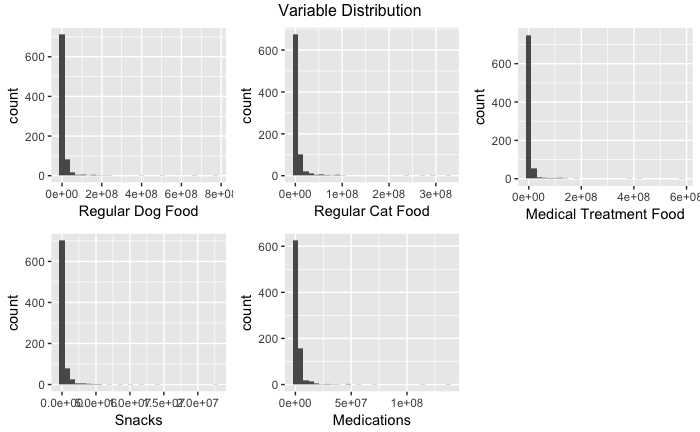

```r
p1<-ggplot(customersData, mapping = aes(x=customersData$Food.Dog)) +
  geom_histogram() + xlab("Regular Dog Food")
p2<-ggplot(customersData, mapping = aes(x=customersData$Food.Cat)) +
  geom_histogram() + xlab("Regular Cat Food")
p3<-ggplot(customersData, mapping = aes(x=customersData$Medical.treatment.Dog)) +
  geom_histogram() + xlab("Medical Treatment Food")
p4<-ggplot(customersData, mapping = aes(x=customersData$Snacks)) +
  geom_histogram() + xlab("Snacks")
p5<-ggplot(customersData, mapping = aes(x=customersData$Medical)) +
  geom_histogram() + xlab("Medications")
grid.arrange(p1,p2,p3,p4,p5,ncol=3, top="Variable Distribution")
```

Based on the charts I decided to use a natural logarithm transformation to reduce the skewness. Since the data contained 0 value registers, I used log1p to manage this issue.

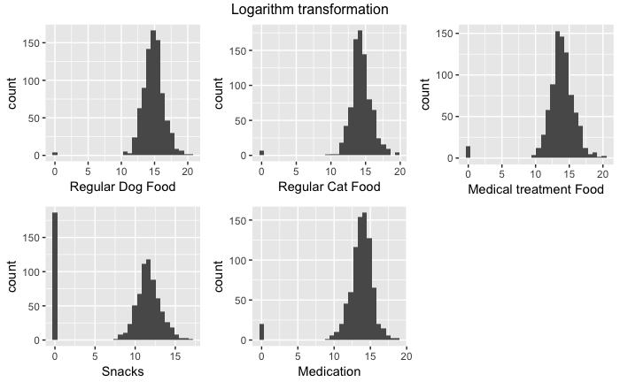

```r
lp1<-ggplot(customersData, mapping = aes(x=log1p(customersData$Food.Dog))) +
  geom_histogram() + xlab("Regular Dog Food")
lp2<-ggplot(customersData, mapping = aes(x=log1p(customersData$Food.Cat))) +
  geom_histogram() + xlab("Regular Cat Food")
lp3<-ggplot(customersData, mapping = aes(x=log1p(customersData$Medical.treatment.Dog))) +
  geom_histogram() + xlab("Medical treatment Food")
lp4<-ggplot(customersData, mapping = aes(x=log1p(customersData$Snacks))) +
  geom_histogram() + xlab("Snacks")
lp5<-ggplot(customersData, mapping = aes(x=log1p(customersData$Medical))) +
  geom_histogram() + xlab("Medication")
grid.arrange(lp1,lp2,lp3,lp4,lp5,ncol=3, top="Logarithm transformation")
```

Jumping to the other variables: VIP, GENERAL, PLATINO, DORADO, EQUINO, ESTELAR. The VIP and GENERAL variables reffer to the numbers of items for each category, PLATINO, DORADO, EQUINO and ESTELAR reffer to the product portfolio. These variables are important to take into account since the commercial agents are divided based on the type of category and portfolio.

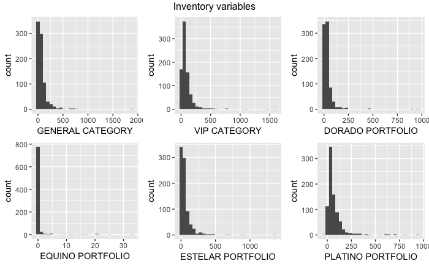

```r
cp1<-ggplot(customersData, mapping = aes(x=GENERAL)) +
  geom_histogram() + xlab("GENERAL CATEGORY")
cp2<-ggplot(customersData, mapping = aes(x=VIP)) +
  geom_histogram() + xlab("VIP CATEGORY")
cp3<-ggplot(customersData, mapping = aes(x=DORADO)) +
  geom_histogram() + xlab("DORADO PORTFOLIO")
cp4<-ggplot(customersData, mapping = aes(x=EQUINO)) +
  geom_histogram() + xlab("EQUINO PORTFOLIO")
cp5<-ggplot(customersData, mapping = aes(x=ESTELAR)) +
  geom_histogram() + xlab("ESTELAR PORTFOLIO")
cp6<-ggplot(customersData, mapping = aes(x=PLATINO)) +
  geom_histogram() + xlab("PLATINO PORTFOLIO")
grid.arrange(cp1,cp2,cp3,cp4,cp5,cp6, ncol=3, top="Inventory variables")
```

I decided to find the proportion of the VIP variable based on the total amount of items, GENERAL+VIP. Similarly, I followed the same approach to the portfalio variables:

| VIP.PP | DORADO.PP | EQUINO.PP | ESTELAR.PP | PLATINO.PP |
| --- | --- | --- | --- | --- |
| 0.7112802 | 0.43017010 | 0.001790510 | 0.13965980 | 0.428379588 |
| 0.2917922 | 0.17620482 | 0.007530120 | 0.51242470 | 0.303840361 |
| 0.6542343 | 0.39096095 | 0.007459412 | 0.28609039 | 0.315489250 |
| 0.4176707 | 0.27710843 | 0.008032129 | 0.29317269 | 0.421686747 |
| 0.4487594 | 0.18122977 | 0.000000000 | 0.47464941 | 0.344120820 |
| 0.4093178 | 0.24792013 | 0.000000000 | 0.25790349 | 0.494176373 |
| 0.5559247 | 0.21262458 | 0.000000000 | 0.34219269 | 0.445182724 |
| 0.6094350 | 0.24794295 | 0.001097093 | 0.39769611 | 0.353263851 |
| 0.4931087 | 0.19142420 | 0.006125574 | 0.28483920 | 0.517611026 |
| 0.6739320 | 0.21621622 | 0.000000000 | 0.25021796 | 0.533565824 |

[output cut: 818 more lines]

To finish the dataset preprocessing, I cleared some variables and did the logarithm transformation.

```r
customersDataTrans<-customersData
customersDataTrans$Customer_ID<-NULL
customersDataTrans$GENERAL<-NULL
customersDataTrans$VIP<-NULL
customersDataTrans$DORADO<-NULL
customersDataTrans$EQUINO<-NULL
customersDataTrans$ESTELAR<-NULL
customersDataTrans$PLATINO<-NULL
customersDataTrans[,1:5]<-log1p(customersDataTrans[,1:5])
glimpse(customersDataTrans)
```

```
Observations: 828
Variables: 12
$ Food.Dog              <dbl> 20.32525, 20.46340, 20.02717, 19.82064, 19.34630, 19.14157, 19.07...
$ Food.Cat              <dbl> 19.60755, 19.48656, 19.40942, 19.30144, 18.37150, 18.37737, 18.29...
$ Medical.treatment.Dog <dbl> 20.18412, 19.84749, 19.74325, 18.97859, 18.54867, 18.68738, 18.56...
$ Snacks                <dbl> 16.47821, 16.93354, 16.12404, 16.25665, 15.09981, 15.92883, 14.87...
$ Medical               <dbl> 17.82135, 18.73833, 18.56205, 17.25022, 17.49676, 16.86414, 17.71...
$ based_segment         <fctr> PLAN_NEGOCIO, PLAN_NEGOCIO, ALIADO, ALIADO, PLAN_NEGOCIO, PLAN_N...
$ region                <fctr> Bogota, Bogota, Bogota, Medellin, Cali, Bogota, Bogota, Bogota, ...
$ VIP.PP                <dbl> 0.7112802, 0.2917922, 0.6542343, 0.4176707, 0.4487594, 0.4093178,...
$ DORADO.PP             <dbl> 0.43017010, 0.17620482, 0.39096095, 0.27710843, 0.18122977, 0.247...
$ EQUINO.PP             <dbl> 0.001790510, 0.007530120, 0.007459412, 0.008032129, 0.000000000, ...
$ ESTELAR.PP            <dbl> 0.1396598, 0.5124247, 0.2860904, 0.2931727, 0.4746494, 0.2579035,...
$ PLATINO.PP            <dbl> 0.4283796, 0.3038404, 0.3154892, 0.4216867, 0.3441208, 0.4941764,...
```

## PCA STUDY

Based on interviews made during the consultancy, customers differs their mix of product based on the type of customer, for example a veterinary clinic tends to buy more medical treatment items than day to day food; on the other hand pet shops tend to buy day to day items rather than medical ones. Doing a PCA study I complemented these business insights with the data.

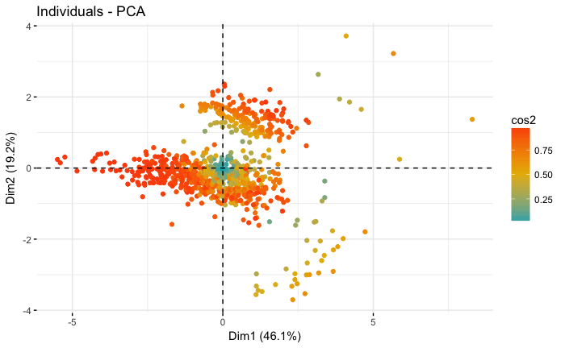

```r
pca.data<-customersDataTrans[,1:5]
pca.var<-prcomp(pca.data, scale. = T)
fviz_pca_ind(pca.var,
             col.ind = "cos2", # Color by the quality of representation
             gradient.cols = c("#00AFBB", "#E7B800", "#FC4E07"),
             repel = TRUE,     # Avoid text overlapping
             geom = c("point"),
             axes = c(1,2)
             )
```

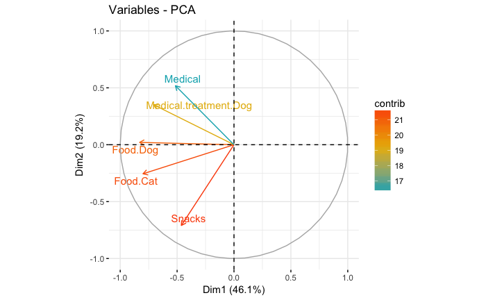

```r
fviz_pca_var(pca.var,
             col.var = "contrib", # Color by contributions to the PC
             gradient.cols = c("#00AFBB", "#E7B800", "#FC4E07"),
             repel = TRUE,     # Avoid text overlapping
             axes = c(1,2)
             )
```

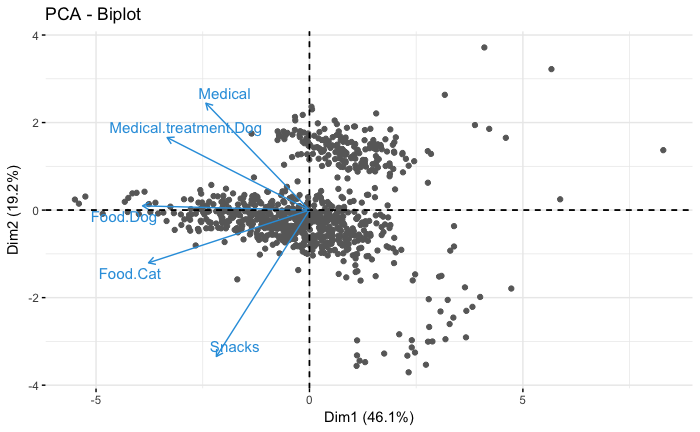

```r
fviz_pca_biplot(pca.var, repel = TRUE,
                col.var = "#2E9FDF", # Variables color
                col.ind = "#696969",  # Individuals color
                geom = c("point")
                )
```

[figure not shown]

```r
Kclusters
```

```
K-means clustering with 3 clusters of sizes 368, 186, 274

Cluster means:
  Food.Dog Food.Cat Medical.treatment.Dog   Snacks  Medical    VIP.PP DORADO.PP    EQUINO.PP ESTELAR.PP
1 13.83058 13.54452              12.49864 11.00519 12.56440 0.5805493 0.1954243 0.0008794327  0.2980729
2 14.42755 13.50644              13.62097  0.00000 13.21222 0.5885256 0.2411511 0.0058998151  0.3766229
3 16.28629 15.76840              15.48952 12.66655 14.84551 0.5456154 0.2168431 0.0017286312  0.3251503
  PLATINO.PP
1  0.5056234
2  0.3763262
3  0.4562780

Clustering vector:
  [1] 3 3 3 3 3 3 3 3 3 3 3 3 3 3 3 3 3 3 3 3 3 3 3 3 3 3 3 3 3 3 3 3 3 3 3 3 3 3 3 3 3 3 3 3 3 3 3 3 3 3 3
 [52] 3 3 3 3 3 3 3 3 3 3 3 3 3 3 3 3 3 3 3 3 2 3 3 3 3 3 3 3 3 3 3 3 3 3 3 3 3 3 3 3 3 3 3 3 3 3 3 3 3 3 3
[103] 3 3 3 3 3 3 3 3 2 2 3 3 3 3 3 2 3 3 3 1 3 3 3 3 3 3 3 2 3 3 2 2 3 3 3 3 3 3 2 3 3 3 3 3 3 2 3 3 3 2 3
[154] 3 3 2 2 3 3 3 3 3 3 2 3 2 2 3 3 3 2 3 3 3 3 3 2 3 3 3 2 3 3 2 3 3 3 3 3 3 3 3 2 3 3 3 3 3 3 3 3 3 3 3
[205] 3 3 3 3 3 2 3 1 3 3 3 3 3 3 3 2 2 3 3 3 3 3 3 2 3 1 2 3 3 3 2 3 2 3 3 2 2 2 1 3 3 3 3 1 2 2 3 1 1 3 2
[256] 3 3 1 3 2 3 3 1 3 3 2 3 3 2 3 3 1 1 3 3 3 3 3 3 2 3 2 1 3 1 3 2 3 2 2 2 3 3 3 3 2 3 3 1 2 1 3 3 3 3 3
[307] 2 2 2 1 1 3 1 3 1 3 3 3 3 1 3 2 3 2 3 1 1 1 3 1 1 1 3 3 1 1 1 3 2 3 1 1 3 3 1 3 3 1 3 3 3 2 1 2 2 1 2
[358] 3 3 2 2 1 3 1 3 1 2 1 1 1 1 2 1 1 1 1 2 2 2 1 1 2 2 1 3 1 1 1 1 2 1 1 2 1 1 1 1 1 1 2 2 1 1 1 1 1 1 3
[409] 1 1 1 1 1 2 2 2 1 1 2 1 1 2 1 2 1 2 1 2 1 1 1 1 1 1 1 1 1 1 1 1 1 1 1 1 2 1 1 2 1 1 1 1 1 1 2 1 1 2 2
[460] 2 1 1 1 1 2 2 1 1 2 1 1 2 1 1 2 2 1 1 1 1 2 1 1 1 1 1 1 1 2 2 2 2 2 1 2 1 2 1 1 1 1 2 1 2 1 1 2 2 1 1
[511] 1 1 2 1 2 2 1 1 2 1 2 1 1 1 2 2 2 2 1 1 2 1 1 2 1 1 1 2 1 1 1 1 2 1 1 1 1 1 2 1 1 1 1 1 1 2 1 2 1 1 1
[562] 1 1 1 1 1 1 1 1 2 2 1 2 2 1 1 1 1 1 1 1 1 1 1 1 1 1 1 1 1 1 1 2 1 1 1 1 2 1 1 1 1 2 2 1 1 1 1 1 2 2 1
[613] 1 2 1 1 1 1 2 1 2 1 1 1 1 1 1 2 1 2 2 2 1 1 1 1 2 2 1 1 1 2 2 2 1 1 1 1 1 1 1 1 1 1 1 1 1 1 1 1 2 1 1
[664] 1 1 1 1 1 1 1 2 1 1 1 1 1 1 1 2 2 1 1 1 1 2 2 2 2 1 1 1 1 1 1 2 1 1 1 1 2 1 2 1 1 1 1 1 1 2 1 2 1 1 1
[715] 1 1 2 2 1 1 2 2 1 2 2 1 2 1 1 1 1 1 1 1 2 1 2 1 1 2 1 1 1 2 1 2 1 2 2 1 1 2 2 1 1 2 1 1 2 2 1 1 2 1 1
[766] 1 2 1 1 1 1 1 1 1 1 1 1 1 1 1 2 2 1 1 1 1 2 1 1 1 1 2 1 2 2 2 1 2 2 1 1 2 1 1 1 1 1 1 1 1 1 1 1 2 2 1
[817] 1 1 1 2 1 1 2 1 1 1 2 1

Within cluster sum of squares by cluster:
[1] 8333.586 2454.266 1995.272
 (between_SS / total_SS =  65.6 %)

Available components:

[1] "cluster"      "centers"      "totss"        "withinss"     "tot.withinss" "betweenss"
[7] "size"         "iter"         "ifault"
```

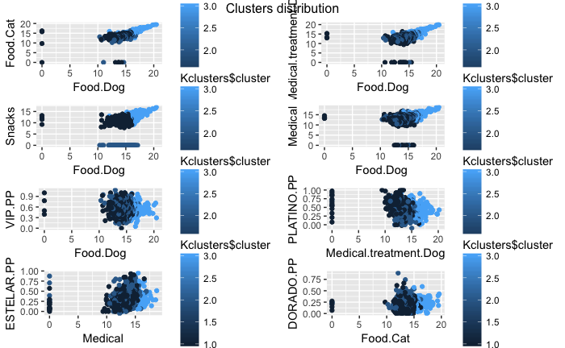

```r
cp1<-ggplot(customersDataTrans, mapping = aes(x=Food.Dog, y=Food.Cat, color=Kclusters$cluster)) +
  geom_point()
cp2<-ggplot(customersDataTrans, mapping = aes(x=Food.Dog, y=Medical.treatment.Dog, color=Kclusters$cluster)) +
  geom_point()
cp3<-ggplot(customersDataTrans, mapping = aes(x=Food.Dog, y=Snacks, color=Kclusters$cluster)) +
  geom_point()
cp4<-ggplot(customersDataTrans, mapping = aes(x=Food.Dog, y=Medical, color=Kclusters$cluster)) +
  geom_point()
cp5<-ggplot(customersDataTrans, mapping = aes(x=Food.Dog, y=VIP.PP, color=Kclusters$cluster)) +
  geom_point()
cp6<-ggplot(customersDataTrans, mapping = aes(x=Medical.treatment.Dog, y=PLATINO.PP, color=Kclusters$cluster)) +
  geom_point()
cp7<-ggplot(customersDataTrans, mapping = aes(x=Medical, y=ESTELAR.PP, color=Kclusters$cluster)) +
  geom_point()
cp8<-ggplot(customersDataTrans, mapping = aes(x=Food.Cat, y=DORADO.PP, color=Kclusters$cluster)) +
  geom_point()
grid.arrange(cp1, cp2, cp3,cp4, cp5, cp6, cp7, cp8, ncol=2, top="Clusters distribution")
```

## CONCLUSIONS

Since the consultancy was to determine a new relationship experience offer to customers, it was very important to clarify the difference between the current segmentation and the new propose one and why it was a better approach to accomplish the new strategic goals set by the company fo the future 5 years.

```r
#Differences between clusters and segmentation
table(Kclusters$cluster,customersData$based_segment)
```

```
      0 Aliado ALIADO EMPLEADO Estándar  HN INACTIVOS PLAN DE NEGOCIO PLAN DE NEGOCIO  PLAN_NEGOCIO
  1   0      0     23        0      275   0         0               0                0           70
  2   0      0     24        0      115   0         0               0                0           47
  3   0      0    118        0       52   0         0               0                0          104
```

The proposed customer experience strategy was based on this analysis changing key logistics processes, customer service, customer retention strategy, marketing campaign targets and social media content.

## REFERENCES

For more information about this project you can contact: VICENTE LACAMBRA email: vicente@grupolaera.com linkedIn profile: https://www.linkedin.com/in/vicente-lacambra-23595138/ https://www.linkedin.com/company/2381565/ http://grupolaera.com/en/